# Stochastic simulation

PCB 6455 / BSC 4933: Biometry | Lecture 13

Dr. Brian Maitner

## Today’s agenda

- The midterm
- What a simulation is, and why you would run one
- Building a simulation: a curve, plus noise
- Groups, and how to simulate them
- Choosing the model, the distribution and the numbers
- Three worked examples on real data

Type and run on a code block: type it into your script and run it. You will need it later. Code without the label is there to watch.

## The midterm

## The midterm: three parts

**Take-home. Due Tuesday Oct 13, 11:59 pm.** Same dataset you have been using.

| Part | What | Weight |
| --- | --- | --- |
| 1 | A short partial paper: introduction, methods, results with figures | 60% |
| 2 | Given data, decide what model and distribution fit | 30% |
| 3 | A power analysis | 10% |

Any tools you like for code, including AI. **Part 1 text must be yours.**

## What each part uses

**Part 1:** your dataset, Assignment 1 figures, Assignment 2 distributions. Mostly writing.

**Part 2:** three datasets I give you. Chapter 3 shapes, chapter 4 distributions. This is Assignment 2 with harder data.

**Part 3:** simulate, analyze, repeat, count. How does **noise** change your chance of detecting a real effect? Today plus Thursday.

Nothing in it is new. It is the semester so far, assembled.

## Getting started on the midterm

The data and starter code are in the course repository:

```r
library(readr)

twoa <- read_rds("https://github.com/bmaitner/biometry_course/raw/refs/heads/main/midterm/midterm_2026_2a.RDS")
twob <- read_rds("https://github.com/bmaitner/biometry_course/raw/refs/heads/main/midterm/midterm_2026_2b.RDS")
twoc <- read_rds("https://github.com/bmaitner/biometry_course/raw/refs/heads/main/midterm/midterm_2026_2c.RDS")
```

`midterm/midterm_2026_example.R` also has the power analysis skeleton for Part 3.

## Any questions about the midterm?

## What is a simulation?

**Experimentation with the help of a model.**

Choose a model, choose parameters, generate data, see what happens.

You already have both pieces:

- **Chapter 3:** a function for the expected value
- **Chapter 4:** a distribution for the noise around it

## Why simulate?

- **Study design.** How many samples do I need to detect this effect?
- **Model checking.** Does my model produce data that look like my data?
- **Method checking.** Does this analysis recover the answer I put in?
- **Theory.** What happens if I add this mechanism?

The second and third are why this is not optional: it is how you find out whether your analysis works **before** you trust it.

## The recipe

1. Pick a model, the deterministic part
2. Pick parameters
3. Add noise from a distribution
4. Look at the output
5. Change something and repeat

## Start with the deterministic part

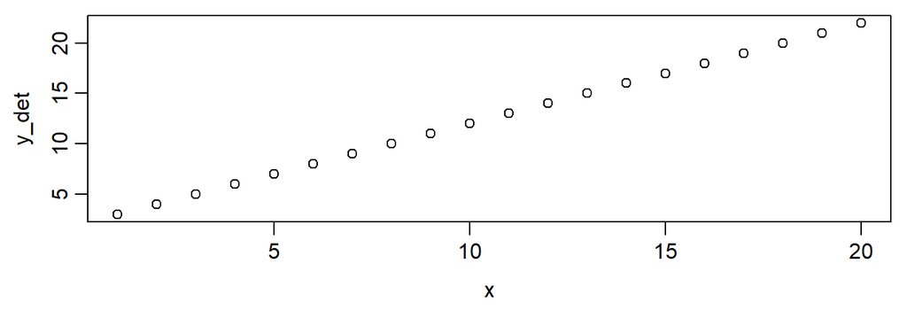

```r
a <- 2
b <- 1
x <- 1:20

y_det <- a + b * x

plot(x = x, y = y_det)
```

A line: $y = a + bx$. No randomness yet.

## Now add noise

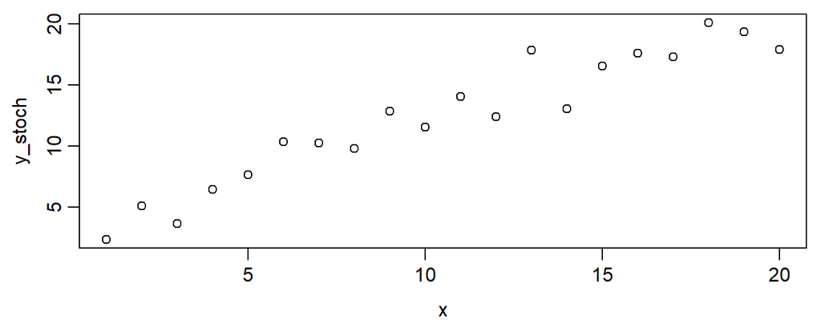

```r
y_stoch <- rnorm(n = 20, mean = y_det, sd = 2)

plot(x = x, y = y_stoch)
```

`mean = y_det` is the trick: **a different mean for every point.**

## Run it again

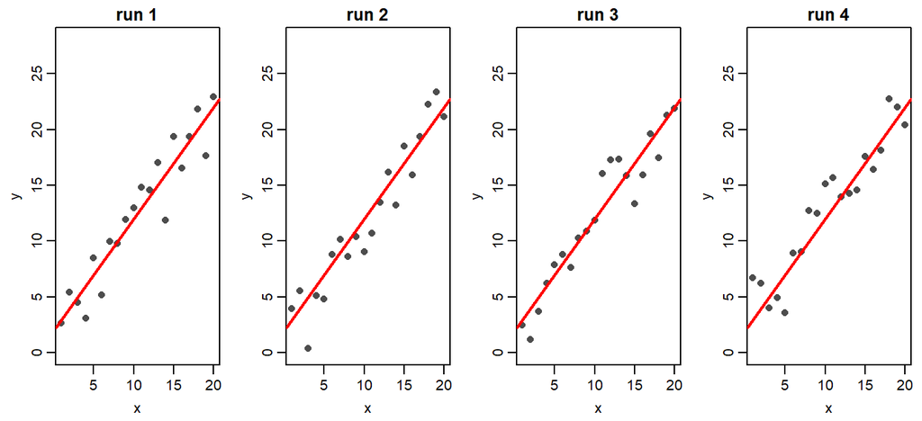

```r
y_stoch <- rnorm(n = 20, mean = y_det, sd = 2)
plot(x = x, y = y_stoch)
```

Same model, same parameters, four different datasets.

## When the noise grows with the mean

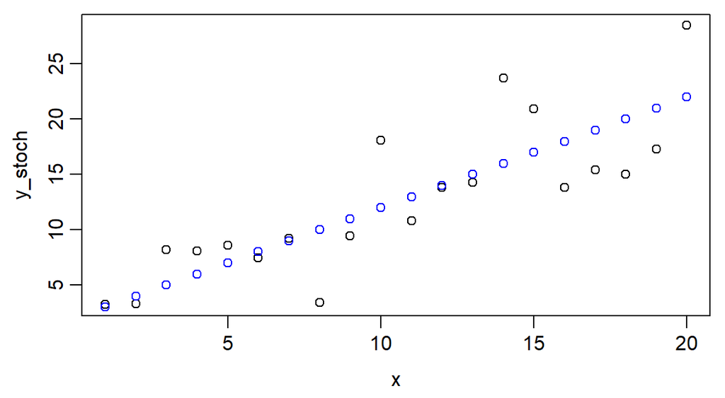

```r
sd_multiplier <- 0.3

y_stoch <- rnorm(n = 20, mean = y_det, sd = y_det * sd_multiplier)

plot(x = x, y = y_stoch)
points(x, y_det, col = "blue")
```

Bigger things vary more. Very common in biology.

## Your turn: break it

```r
a <- 2
b <- 1
x <- 1:20
y_det <- a + b * x

y_stoch <- rnorm(n = 20, mean = y_det, sd = 2)
plot(x = x, y = y_stoch)
abline(a = a, b = b, col = "red")

# now try
# sd = 0.1    sd = 20    b = 0    b = -1
```

How big does `sd` have to be before the line is invisible in the data?

## A curve instead of a line

Bolker’s example: a hyperbolic function with **negative binomial** noise.

$$y = \frac{a\,b}{b + x}$$

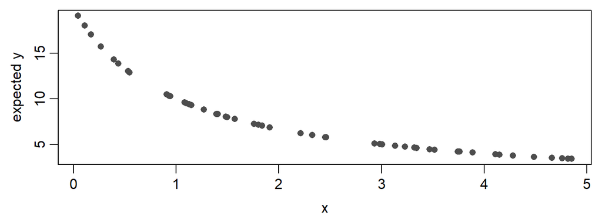

Why would a normal error term be wrong here?

## Adding negative binomial noise

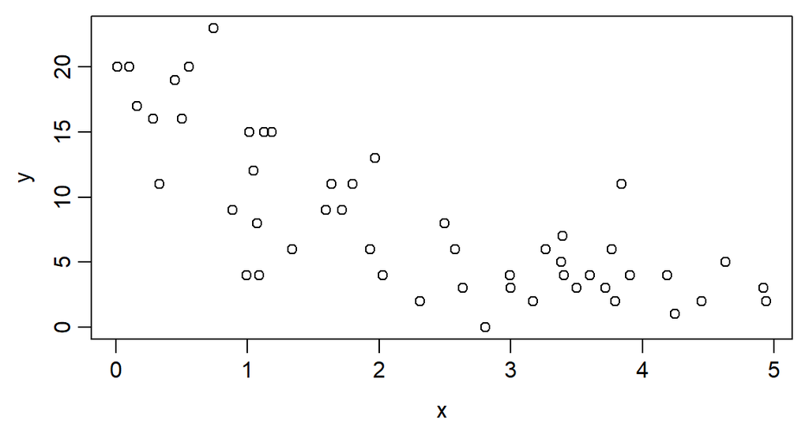

```r
a <- 20
b <- 1
k <- 5
x <- runif(50, min = 0, max = 5)

y_det <- a * b / (b + x)
y <- rnbinom(n = 50, mu = y_det, size = k)

plot(x = x, y = y)
```

## Your turn: what does each parameter do?

```r
a <- 20
b <- 1
k <- 5
x <- runif(50, min = 0, max = 5)

y_det <- a * b / (b + x)
y <- rnbinom(n = 50, mu = y_det, size = k)

plot(x = x, y = y, ylim = c(0, 60))
points(x, y_det, col = "blue", pch = 16)
```

Try `k = 0.5` and `k = 100`. Then `a = 50`. Then `b = 3`.

## Groups

## Different species, different parameters

Two species, 25 observations each. They differ in `a` and `b`, but share the same noise.

```r
g <- factor(rep(1:2, each = 25))

a <- c(20, 10)
b <- c(1, 2)
```

`a` and `b` are now **vectors**, one value per group.

## Indexing by group

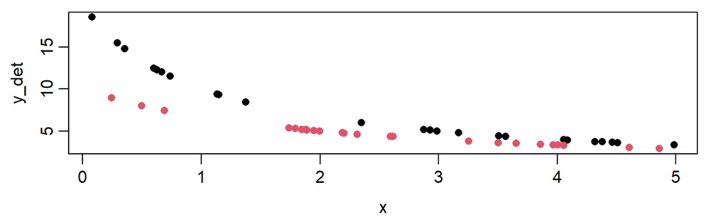

```r
x <- runif(50, min = 0, max = 5)

y_det <- a[g] * b[g] / (b[g] + x)

plot(x = x, y = y_det, col = g, pch = 16)
```

`a[g]` reads “the `a` for whichever group this observation belongs to”.

## Now add the noise

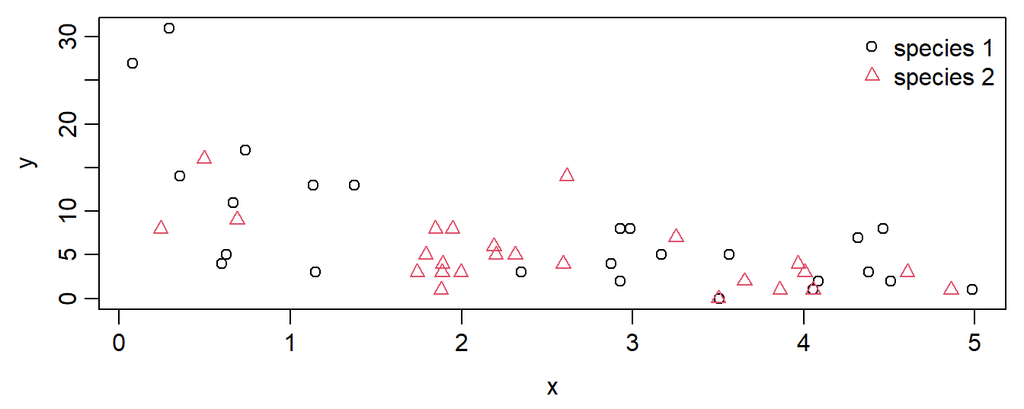

```r
k <- 5

y <- rnbinom(n = 50, mu = y_det, size = k)

plot(x = x, y = y, col = g, pch = as.numeric(g))
legend("topright", bty = "n", col = 1:2, pch = 1:2,
       legend = c("species 1", "species 2"))
```

## Your turn: can you tell them apart?

```r
a <- c(20, 10)      # change these
b <- c(1, 2)
k <- 5

y_det <- a[g] * b[g] / (b[g] + x)
y <- rnbinom(n = 50, mu = y_det, size = k)
plot(x = x, y = y, col = g, pch = as.numeric(g))
```

Find parameters where the two species look **clearly different**. Then find parameters where they look **identical**. Then find parameters where they differ only at **low x**.

## Choosing the pieces

## Three choices, every time

A simulation needs all three before it will run:

1. **The model.** What shape does the average follow?
2. **The distribution.** How do observations scatter around it?
3. **The parameters.** What numbers go in?

You have done the first two already, on real data. Today they get used in the other direction.

## 1. The model: what shape?

From chapter 3, Lectures 9 and 10. Ask three questions of the pattern:

- What happens at the **left end**?
- What happens at the **right end**?
- What happens **in between**: rise, fall, peak, level off, switch?

| Shape | Function |
| --- | --- |
| Straight | $a + bx$ |
| Rises and levels off | Michaelis-Menten, Holling type II |
| Humped | Ricker, power-Ricker |
| Falling | negative exponential |
| Flat then a switch | hockey stick, threshold |

## 2. The distribution: what kind of number?

From chapter 4, Lecture 12. Eliminate, then check:

- **Discrete or continuous?**
- **What range?** 0 to 1, 0 upward, any number
- **What process made it?** Out of a known total, a count with no ceiling, a measurement, a waiting time

Then **use a number, not an impression**:

- Counts: is the variance bigger than the mean? Poisson or negative binomial
- Continuous and positive: is the mean far from the median? Lognormal or gamma

## 3. The parameters: where do the numbers come from?

You have to put numbers in. Four honest sources:

1. **Pilot data.** Even 10 observations give you a rough mean and spread.
2. **Published studies** on the same system, or a similar one. Methods sections and figures have numbers in them.
3. **Your own previous data.** The variance from last season is usually the best guess for next season.
4. **Biological limits.** A proportion is between 0 and 1, a clutch is not 400 eggs, a seedling does not weigh a kilogram.

And when you genuinely do not know: **try a range** and see whether the answer changes.

## The one number nobody can give you

**How big an effect would matter?**

A 2% change in growth rate might be real and still not be worth designing a study around.

Simulate the **smallest effect you would care about**, not the biggest one you hope for.

## Three worked examples, on real data

## Get set up

Run this before the examples. The three of them use these two datasets.

```r
# tadpole predation, from the book's package
library(emdbook)
data(ReedfrogFuncresp)
frogs <- ReedfrogFuncresp

# Breeding Bird Survey counts (about 15 MB, give it a moment)
bbs <- read.csv("https://github.com/bmaitner/biometry_course/raw/refs/heads/main/data/BBS/FL_BBS.csv")

cardinals <- bbs$total_sightings[bbs$Year == 2019 &
                                 bbs$Scientific_Name == "Cardinalis cardinalis"]

length(cardinals)     # should be 71
```

## Example 1: the tadpoles, again

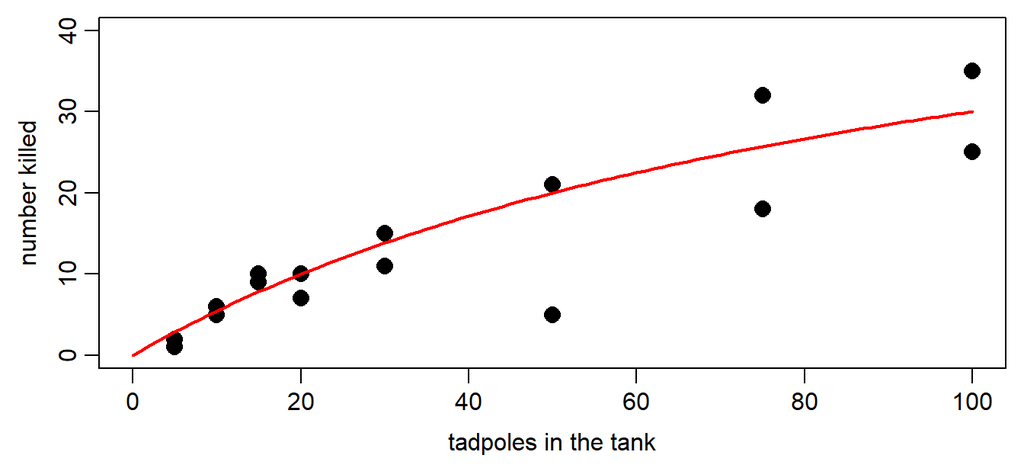

Lecture 10 gave us the curve. Each tank started with a known number, so the kills are **out of** that number: binomial.

## Simulate the experiment

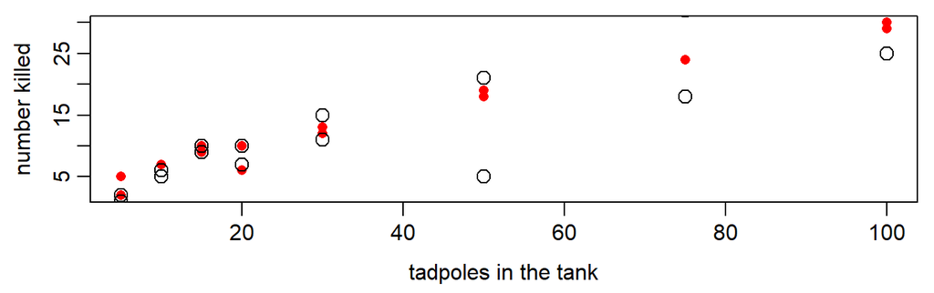

```r
p <- (60 * frogs$Initial / (100 + frogs$Initial)) / frogs$Initial

killed_sim <- rbinom(n = nrow(frogs), size = frogs$Initial, prob = p)

plot(frogs$Initial, killed_sim, pch = 16, col = "red",
     xlab = "tadpoles in the tank", ylab = "number killed")
points(frogs$Initial, frogs$Killed, pch = 1, cex = 1.4)
```

Red: a fake experiment. Open circles: the real one.

## Example 2: counting cardinals

Breeding Bird Survey, Florida, 2019. One count per route, 71 routes.

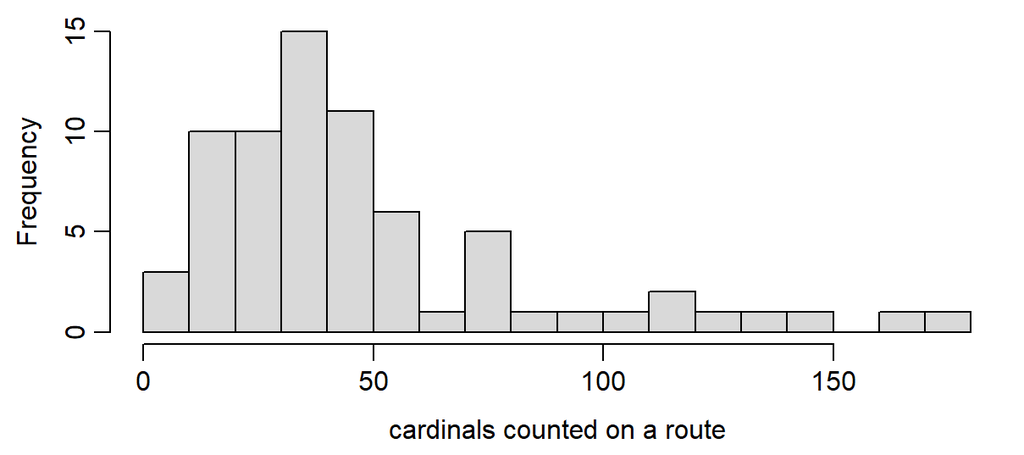

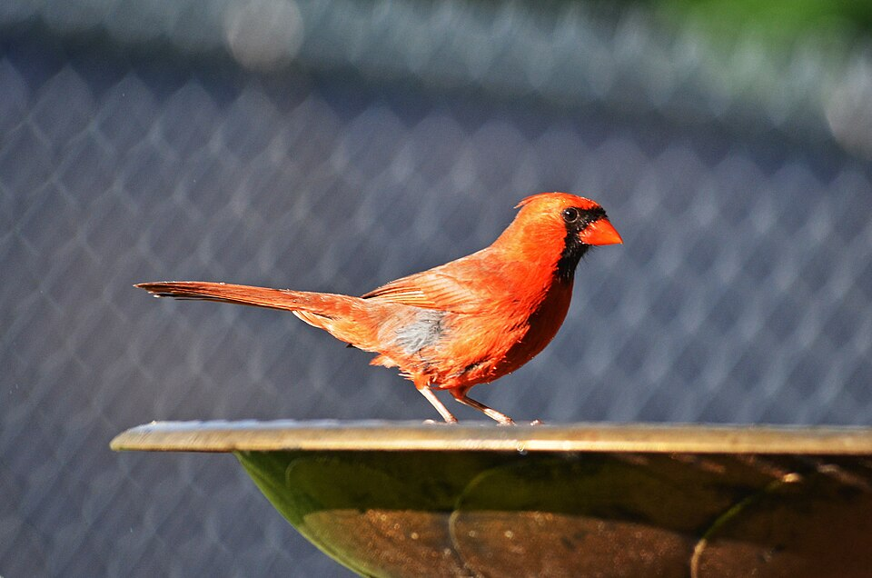

*Cardinalis cardinalis*  
Photo: USFWS, public domain

A count with no ceiling. **Poisson?**

## A Poisson makes a testable claim

```r
mean(cardinals)
```

```
[1] 49.4507
```

```r
var(cardinals)
```

```
[1] 1399.994
```

```r
var(cardinals) / mean(cardinals)
```

```
[1] 28.3109
```

A Poisson has **mean = variance**, so that ratio should be about 1.

It is **28**: far more spread than a Poisson allows.

## Matching a negative binomial, then simulating from it

The negative binomial has a mean and a clumping parameter. Solve for both from the data, then generate fake routes:

```r
mu <- mean(cardinals)
size <- mu^2 / (var(cardinals) - mu)      # about 1.8

fake <- rnbinom(n = 71, mu = mu, size = size)

hist(fake)
hist(cardinals)
```

## Fake routes against real ones

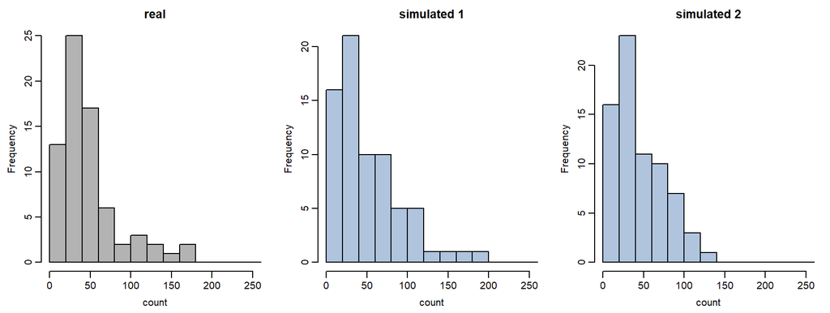

Close enough that you could not pick the real one out of a line-up.

A Poisson would never do this: it cannot make a 175.

## Example 3: how much data do you need to see a shape?

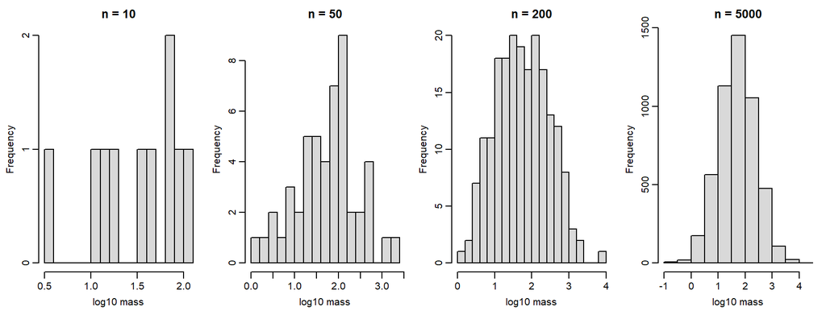

All four are lognormal, with the parameters of real bird masses.

## Your turn: how few is too few?

```r
draws <- rlnorm(n = 20, meanlog = 3.5, sdlog = 1.6)

hist(log10(draws), breaks = 15)

# run it several times at n = 20, then try n = 100, n = 1000
```

At what sample size does the shape stop changing every time you run it?

## You do not always need a curve

| Example | Deterministic part | Distribution |
| --- | --- | --- |
| Tadpoles | Michaelis-Menten curve | binomial |
| Cardinals | just a mean | negative binomial |
| Bird masses | just a mean | lognormal |

A curve is only needed when the expected value **changes with a predictor**. With one variable and no predictor, the distribution is the whole model.

## What the three examples had in common

1. **Build the data your model predicts.**
2. **Compare it to what you actually got.**
3. **Repeat it**, because one dataset is one draw.

That is model checking, and it is most of what simulation is for.

## What simulation buys you: 10 sites or 40?

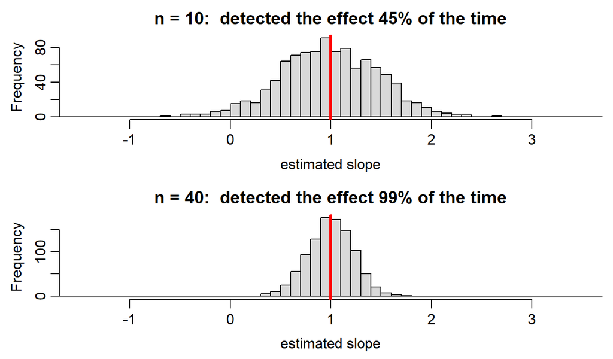

Same truth, same noise. **1000 studies each.**

## Start simple

- Simple models are easier to check and debug
- Complexity adds realism, and new ways to be wrong
- Add one piece at a time, and look after each one

Section **5.2.2.2** has a more complex worked example.

## Before next class

Read Bolker **5.3**

Next time: **power analysis**, which is Part 3 of the midterm